# 9 days of Pokemon Go - a statistical analysis

Juan De Dios Santos, @jdiossantos

August 7, 2016

# Introduction

Pokemon Go is finally out. Like every 90’ kid (and as a huge fan of the series), I have spent a considerable amount time catching our beloved digital creatures. However, besides spending battery life and swiping my screen like a maniac, I also spent some time (mostly while charging my phone) logging some of the data from the in-game events. The purpose of this was to take a statistical look at the patterns, and behaviour of the game as the player progress in the game.

In this analysis I will present, through several images, tables, and statistical models, how the game rewards you as you level up, how the combat power (CP) of the Pokemon increase, and an interesting relationship found the CP and the hit points (HP) of the Pokemon.

Note: If you are looking for a quick read, and are interested in more advanced topics, I suggest to start or just read the last section, titled *Drowzees, Pidgeys, CP and HP*.

# The data

I would like to note that the amount of Pokemon captured and Pokestops visited vary per day, in other words you will see that in some days I had more activity than in others. This means that my data is biased towards some days.

Also, at the start of the experiment my player level was 9, and 18 at the end.

# The Pokemon

The first section of this report focuses on the 297 captured Pokemon. The next table shows a summary of the catches per day, the most frequent Pokemon caught and some basic statistics about the CP.

```
##       Date        Pokemon         CP
##  7/12/16:13   Drowzee :59   Min.   : 10.0
##  7/13/16:57   Pidgey  :54   1st Qu.: 72.0
##  7/14/16:48   Rattata :41   Median :140.0
##  7/15/16:38   Spearow :16   Mean   :174.3
##  7/16/16:23   Zubat   :15   3rd Qu.:238.0
##  7/17/16: 5   Gastly  :11   Max.   :878.0
##  7/18/16:42   Krabby  :10
##  7/19/16:26   Squirtle: 9
##  7/20/16:45   (Other) :82
```

As mentioned during the introduction, the game time activity is quite different across the nine days. On the 17th, apparently the servers were down because I just have a total of 5 captured Pokemon. However the day after that, I went back to business and got a total of 42 Pokemon.

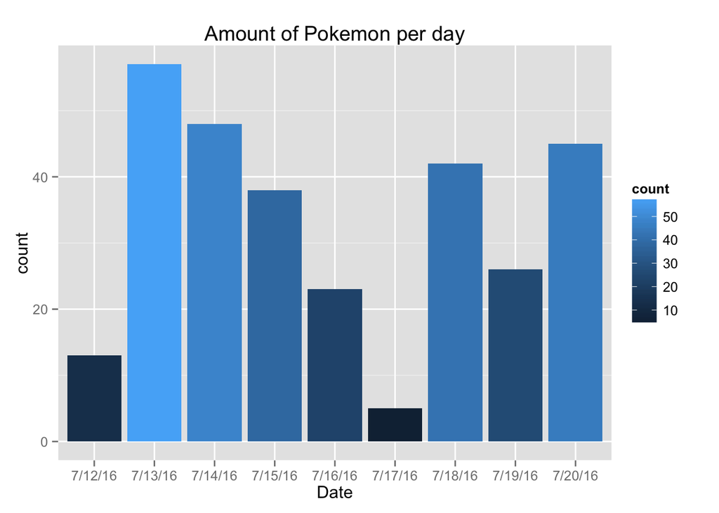

July 13 was the day with the highest activity; a total of 57 were captured. On the other hand, July 17 was a sad day. Just five Pokemon were caught.

Now that I have show the total amount of Pokemon captured, I will proceed to display exactly how many of each specie were caught.

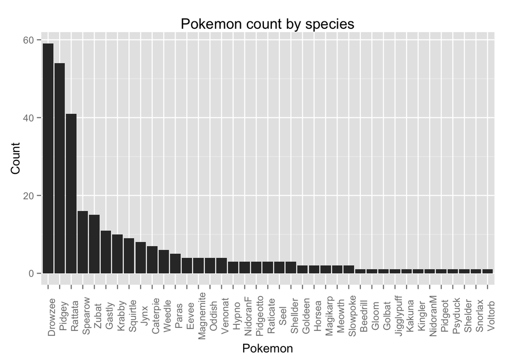

Drowzee seems to be the most common (or one of the most common) Pokemon in my city because during those days I captured a total of 59, or 19.86% if it is compared against the rest. Followed by Drowzee there are 54 Pidgey (18.18%), and in the third position, Rattata, with a total of 41 captures (13.80%). On the other side of the spectrum there is a single Beedrill, Gloom, Golbat, Jigglypuff, Kakuna, Nidoran♂, Pidgeot, Psyduck, Shellder, Snorlax and Voltorb.

Let’s shift our focus to the combat power (CP) of the captured Pokemon. The summary of the data shown before shows that the weakest Pokemon had a CP of 10, while the strongest one was a mighty Snorlax with a CP of 878. But what’s values are in between the weakest and the strongest Pokemon? Let’s take a look.

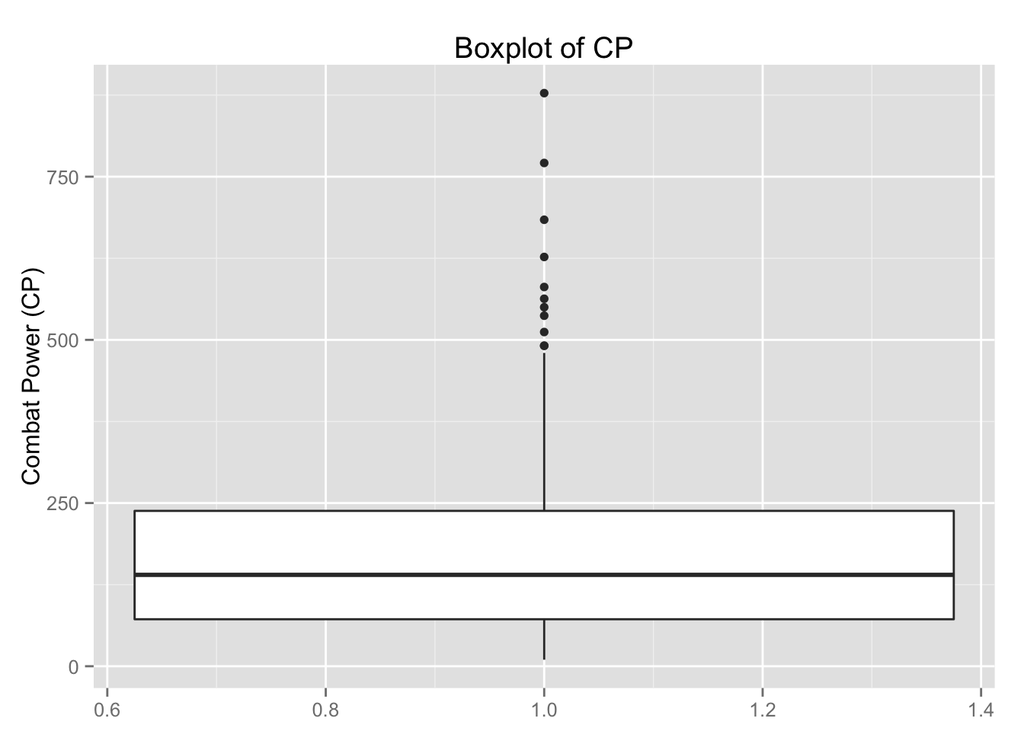

The figure below shows a detailed view the CP for each Pokemon, with the highest ones annotated. As shown in the box plot and the summary, we can see that most of the points are below the 250 mark.

One of my objectives in this section was to see if there is a significant increase of the CP on the latter days. So I took a look at the CP over the nine days and plotted them in several ways.

[figure not shown]

By looking at this I cannot tell much, except of the two main outliers: Snorlax CP 878 and Kingler CP 771.

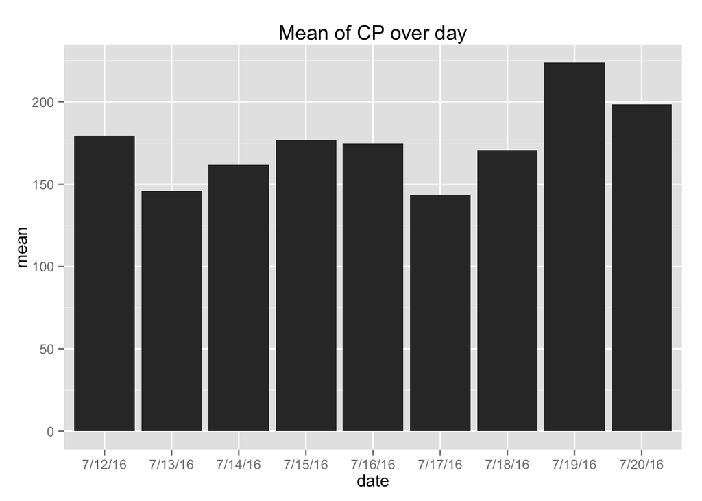

Bonus plots: combat power of all the captured Pokemon and the standard deviation (to complement the mean barplot) of the CP grouped by day.

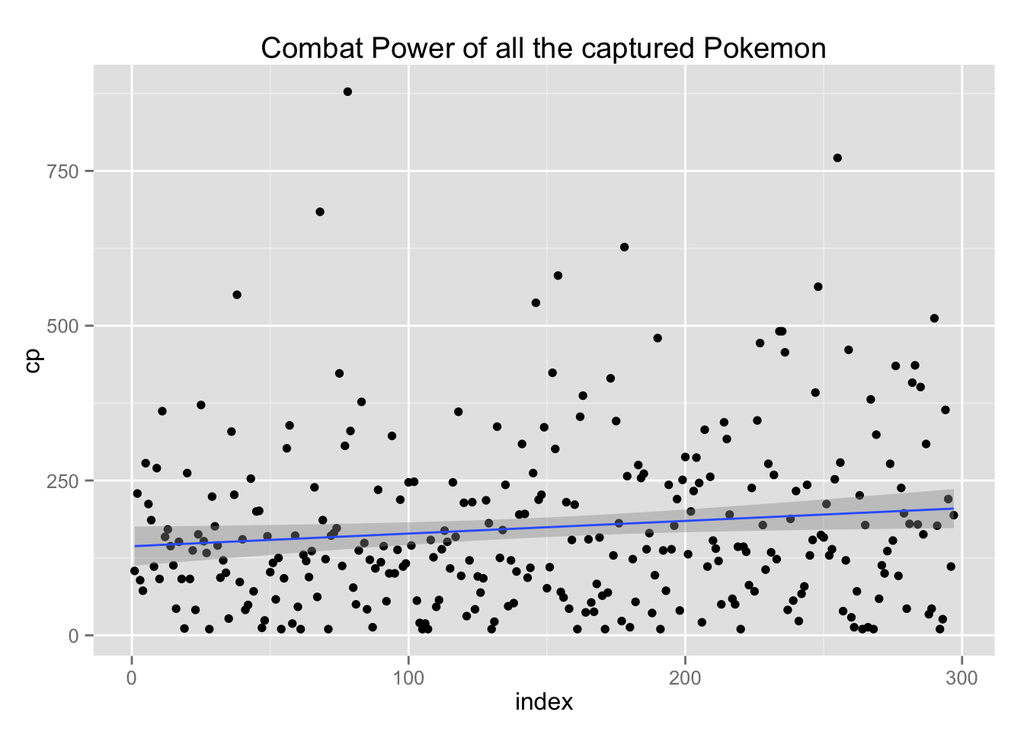

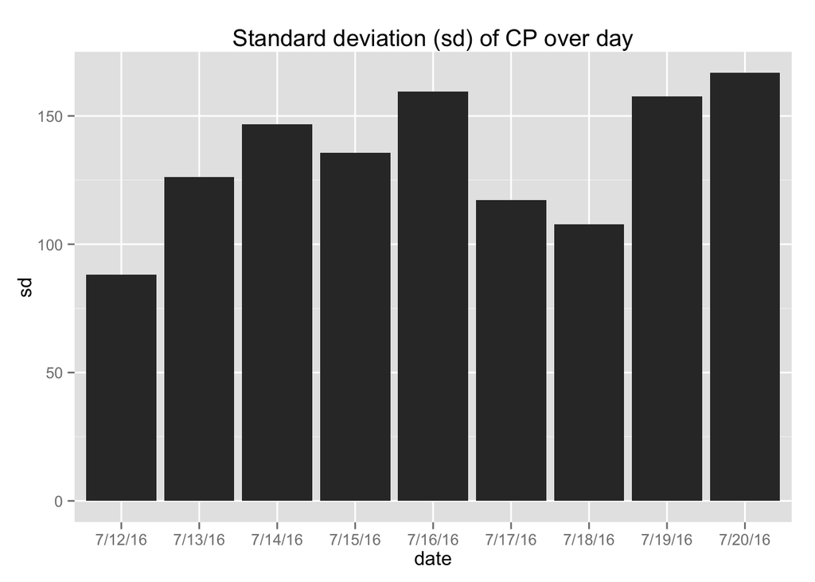

# Items

The total number of items acquired through the Pokestops was 886, an average of 3.27 items per Pokestop. In the following table I will present the frequency of these items, their percentage, and some basic properties of the dataset regarding the quantity of items awarded at each Pokestop.

| Item | Frequency | Percentage | Median | Mean | Standard Deviation |
| --- | --- | --- | --- | --- | --- |
| Pokeball | 546 | 61.62% | 2.00 | 2.02 | 1.01 |
| Great Ball | 103 | 11.62% | 0.00 | 0.38 | 0.58 |
| Potion | 65 | 7.33% | 0.00 | 0.24 | 0.47 |
| Super Potion | 41 | 4.62% | 0.00 | 0.15 | 0.38 |
| Hyper Potion | 7 | 0.79% | 0.00 | 0.03 | 0.16 |
| Razz Berry | 69 | 7.78% | 0.00 | 0.25 | 0.46 |
| Revive | 55 | 6.20% | 0.00 | 0.20 | 0.43 |

According to the data presented in the preceding table Pokeballs were the most common item obtained at the Pokestops, with a final counter of 546 or 61.62%, a median of 2 per stop, a mean of 2.02, and a maximum of 5, meaning that one Pokestop dropped 5 Pokeballs. On the other hand, Hyper Potion was the least common item; just 7 of them were acquired (0.79%). A peculiarity of this data is the fact that the median of all the items, except Pokeball, was 0. The two box plot below display this; on the Pokeball box plot we can clearly see the bold line that states the median, however the second one shows that the data is strongly skewed to the right.

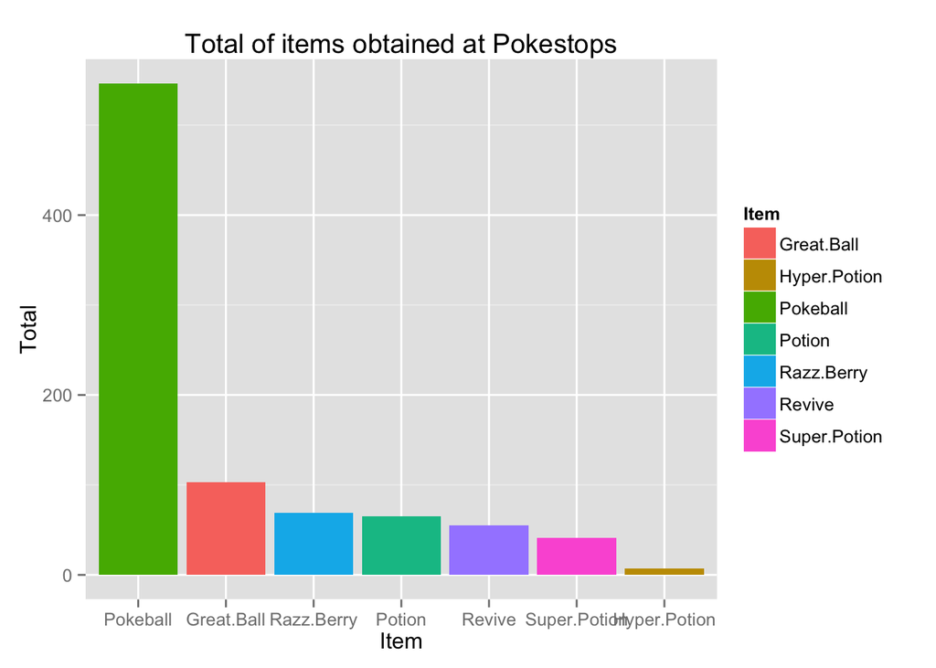

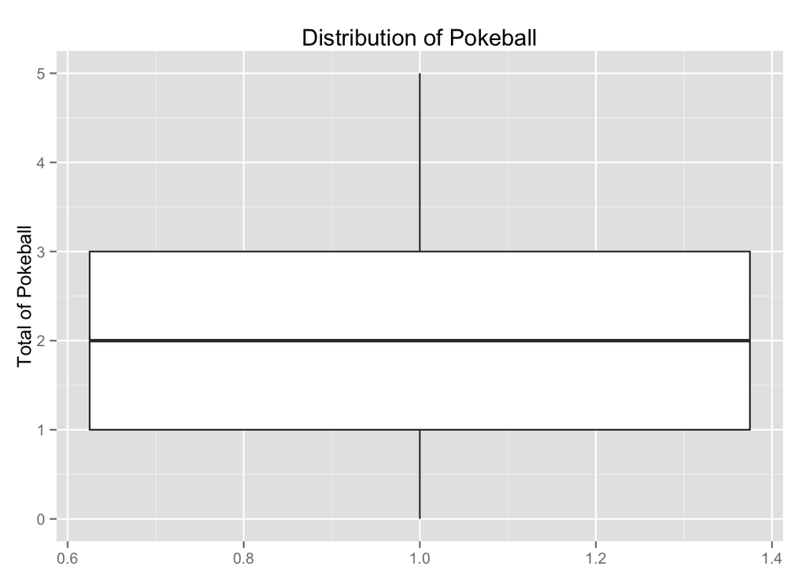

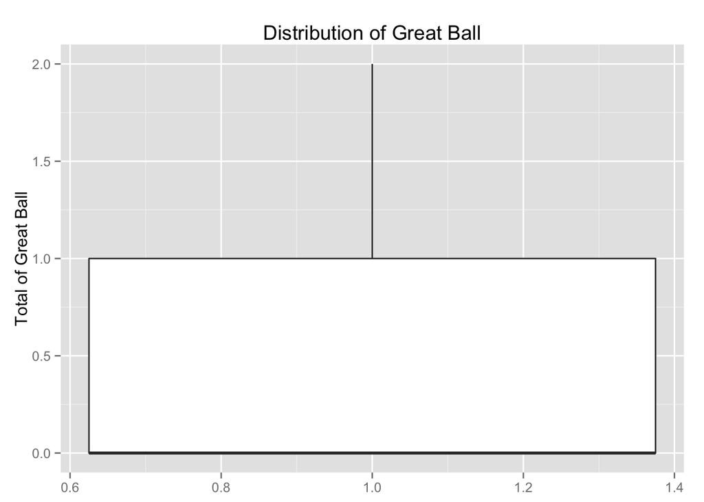

One particular detail I wanted to investigate was the decrease of the amount of potions acquired as the result of leveling up, because I had the assumption that this number would decrease as new items (Super and Hyper Potion), were being unlocked.

[output not shown]

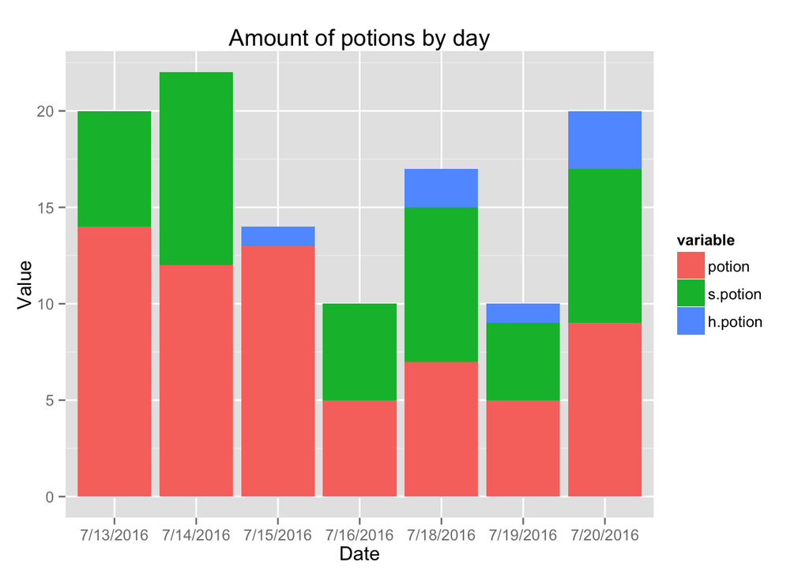

The above table and plot showed that “somehow” my assumption was right because after the first day (with the exception of the third one), the percentage of Potions decreased, while the number of Super and Hyper Potions incremented. However I wouldn’t call this a definitive conclusion due to the small data sample.

# Drowzees, Pidgeys, CP and HP

In Pokemon Go, the higher the combat power (CP) of a Pokemon is, the higher the hit points (HP) is - this is a basic observation can be seen in the first minutes of the game. Despite knowing this, I wanted to see how exactly it worked, so I ran a (simple) linear regression to study this behaviour using the CP and HP of my two most common Pokemon: Drowzee and Pidgey.

In layman’s terms, a simple linear regression is a statistical approach for modelling the relationship between a dependent variable, and one or several independent variables, by fitting a linear equation that is estimated from the data.

This is the equation of a linear regression line: $Y = a+bX$ Where $Y$ is the dependent variable (what we want to predict), in our case this is the HP, $X$ is the independent or explanatory variable, the CP, $a$ is the y-intercept of the value of $y$ when $x=0$, and $b$ is the slope.

Before continuing with the regressions, I would like to state that the observed Pearson’s correlation between the CP and HP for Drowzee is 0.974654, while the one for Pidgey is 0.9796001, an almost perfect positive correlation.

For more information about linear regression I suggest the following [link](http://www.stat.yale.edu/Courses/1997-98/101/linreg.htm), and as for correlations, this [page](https://www.mathsisfun.com/data/correlation.html) offers a quick and easy to follow explanation.

Now, I will present the result of the linear regression using the **Drowzee**.

```
##
## Call:
## lm(formula = HP ~ CP, data = drowzee)
##
## Residuals:
##     Min      1Q  Median      3Q     Max
## -8.2485 -2.5937  0.3972  3.2114  5.8708
##
## Coefficients:
##              Estimate Std. Error t value Pr(>|t|)
## (Intercept) 17.695408   1.412771   12.53 1.72e-14 ***
## CP           0.119470   0.004635   25.77  < 2e-16 ***
## ---
## Signif. codes:  0 '***' 0.001 '**' 0.01 '*' 0.05 '.' 0.1 ' ' 1
##
## Residual standard error: 3.891 on 35 degrees of freedom
## Multiple R-squared:   0.95,  Adjusted R-squared:  0.9485
## F-statistic: 664.3 on 1 and 35 DF,  p-value: < 2.2e-16
```

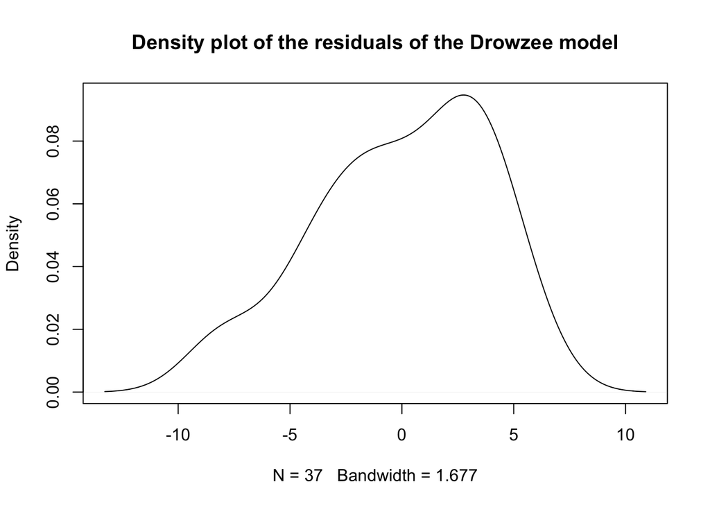

At the top of the summary of the linear regression (the table above) are the residuals. The residuals are the difference between the real value of the variable and the predicted value of the prediction. The residuals for this model are good, the mean practically 0, the standard deviation is 3.89, and a density plot of them shapes a normal distribution.

Another metric that shows that the fit is good is the p-value of the CP variable. Since p-values are a bit hard to understand, and they are out of the scope of this report, just believe me when I say that in this case the smaller the number is, the better, and in this particular case the p-value is $2e-16$ which is really small number.

The last metric I will use to analyse the goodness of the model is the R-squared or coefficient of determination statistic. Like the p-value, this value is also complicated to understand, so once again please bear with me when I say that the closest it is to 1 (not in every case!) the better it is. In this case the R-squared is 0.95.

What about the intercept and the slope? The y-intercept is 17.70, and the slope is 0.12. Thus, the regression line equation is: $Y = 17.70+0.12 * X$, and it looks like this:

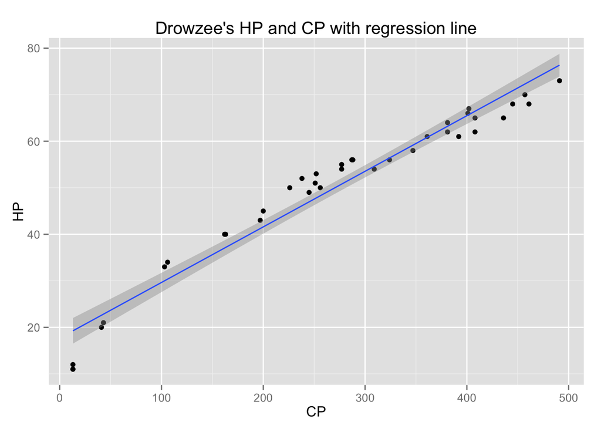

Now the same but for **Pidgey**.

```
##
## Call:
## lm(formula = HP ~ CP, data = pidgey)
##
## Residuals:
##     Min      1Q  Median      3Q     Max
## -6.3258 -1.2390  0.1368  1.1702  5.0646
##
## Coefficients:
##              Estimate Std. Error t value Pr(>|t|)
## (Intercept) 12.037209   0.540687   22.26   <2e-16 ***
## CP           0.144529   0.003893   37.12   <2e-16 ***
## ---
## Signif. codes:  0 '***' 0.001 '**' 0.01 '*' 0.05 '.' 0.1 ' ' 1
##
## Residual standard error: 2.309 on 58 degrees of freedom
## Multiple R-squared:  0.9596, Adjusted R-squared:  0.9589
## F-statistic:  1378 on 1 and 58 DF,  p-value: < 2.2e-16
```

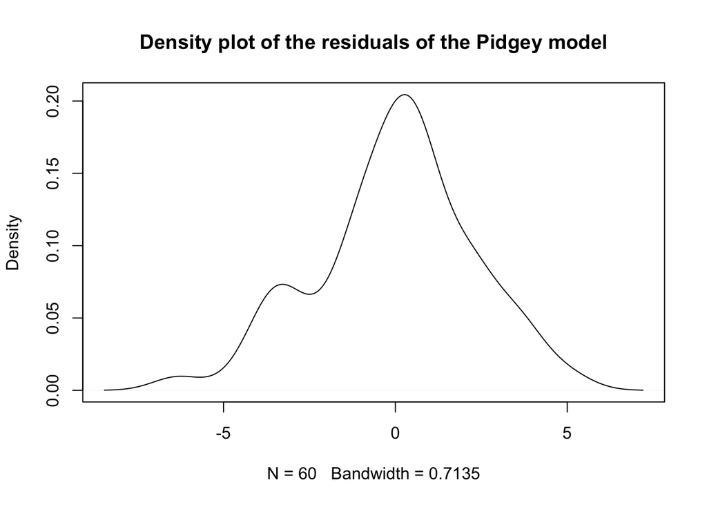

At a single glimpse, I could see that this model is as effective and similar to the previous one. The residuals are acceptable (mean close to 0), and standard deviation of 2.30. The p-value is also really close to 0, and the R-squared is 0.96.

The regression line equation is: $Y = 12.04+0.14 * X$

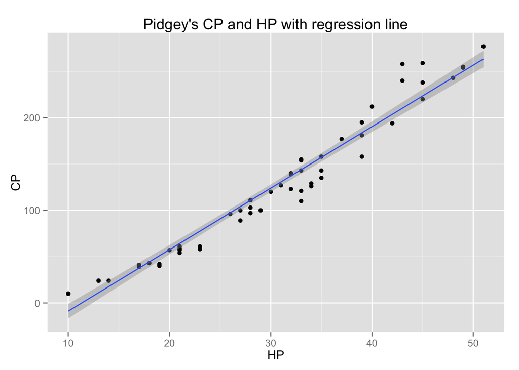

# Conclusion

In this report I presented the results of an experiment done using personal data collected from Pokemon Go during the span of nine days. The analysis started with an overview of the top Pokemon in my area, Drowzee and Pidgey, the evolution of the combat power over time and several stats about it.

The second topic discuss were the items, and how they are distributed.

For the last topic I introduced two linear regressions to study the relationship between the combat power and the hit points of the Pokemon. The results were pretty satisfactory and showed that there is indeed a correlation and linear relationship between both features.

That’s it for now! If you have any suggestions, idea or more data you would like to share, please do.

Thanks for reading.

# Notes and disclaimers

- If you spot a typo, or any error in the analysis, feel free to notify me.
- This work is licensed under a [Creative Commons Attribution-NonCommercial 4.0 International License](http://creativecommons.org/licenses/by-nc/4.0/). In other words, feel free to use it, share it, edit it for non-commercial purposes and please, give credit.
- ©2016 Niantic, Inc. ©2016 Pokémon. ©1995–2016 Nintendo / Creatures Inc. / GAME FREAK inc. Pokémon and Pokémon character names are trademarks of Nintendo.